# Fundermentals of R

Intermediate R - 5.0 Data Visualization

Prepared By Clinton Moshe Mwachia

2023-07-01

## Introduction

Data visualization plays a crucial role in understanding and interpreting data. In R, there are various graphical techniques available to visualize data effectively. In this lesson, we will explore six commonly used visualization methods: scatter plot, line plot, pie chart, bar plot, box-plot, and histogram.

## The data

we will create a data frame that we will use for all the visuals

```r
# the data
data = data.frame(
  subject = c("Math", "Eng", "Kis", "Chem", "Phy", "Hist", "Geo", "Bio", "CRE", "IRE"),
  marks = c(45, 50, 52, 59, 55, 59, 60, 62, 79, 85),
  age = c(15, 18, 25, 45, 49, 45, 58, 65, 69, 79),
  gender = c("M","F","M","F","F","F","M","M","F","M")
)

data
```

```
##    subject marks age gender
## 1     Math    45  15      M
## 2      Eng    50  18      F
## 3      Kis    52  25      M
## 4     Chem    59  45      F
## 5      Phy    55  49      F
## 6     Hist    59  45      F
## 7      Geo    60  58      M
## 8      Bio    62  65      M
## 9      CRE    79  69      F
## 10     IRE    85  79      M
```

## Scatter Plot

A scatter plot is used to visualize the relationship between two continuous variables. It displays individual data points as dots on a two-dimensional plane.

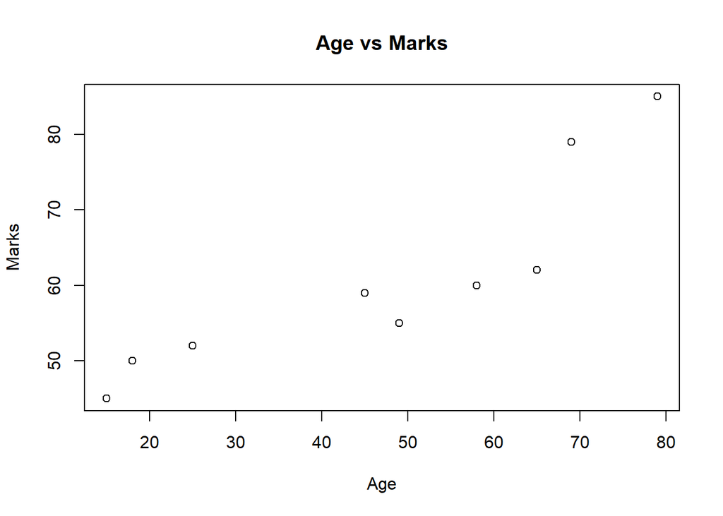

```r
# Scatter plot
plot(data$age, data$marks, main = "Age vs Marks", xlab = "Age", ylab = "Marks")
```

### Interpretation

The scatter plot shows a positive linear relationship between the Age and Marks. As Age increases, Marks also increases, indicating a strong positive correlation.

## Line Plot

A line plot is commonly used to visualize the trend or pattern of a variable over time or another continuous variable.

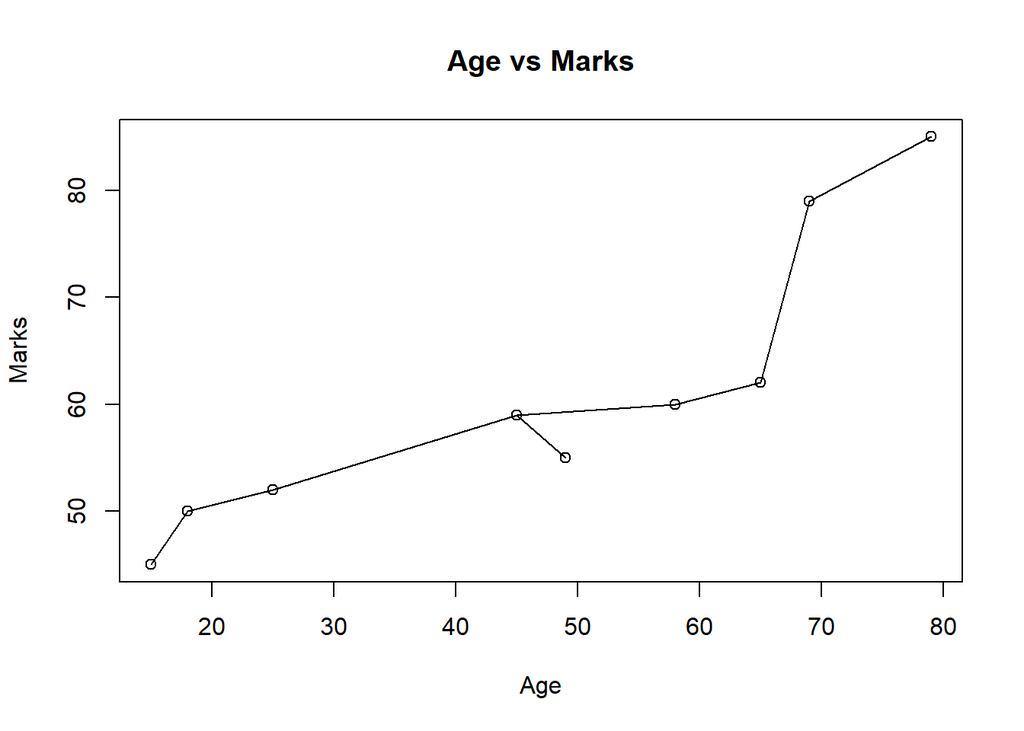

```r
# Line plot
plot(data$age, data$marks, type = "o", main = "Age vs Marks",
     xlab = "Age", ylab = "Marks")
```

### Interpretation

The line plot shows the trend of the Marks over Ages. It indicates an initial increase, followed by a slight decrease and then a further increase.

## Pie Chart

A pie chart is a circular visualization that represents categorical data as slices of a pie, with each slice representing a proportion of the whole.

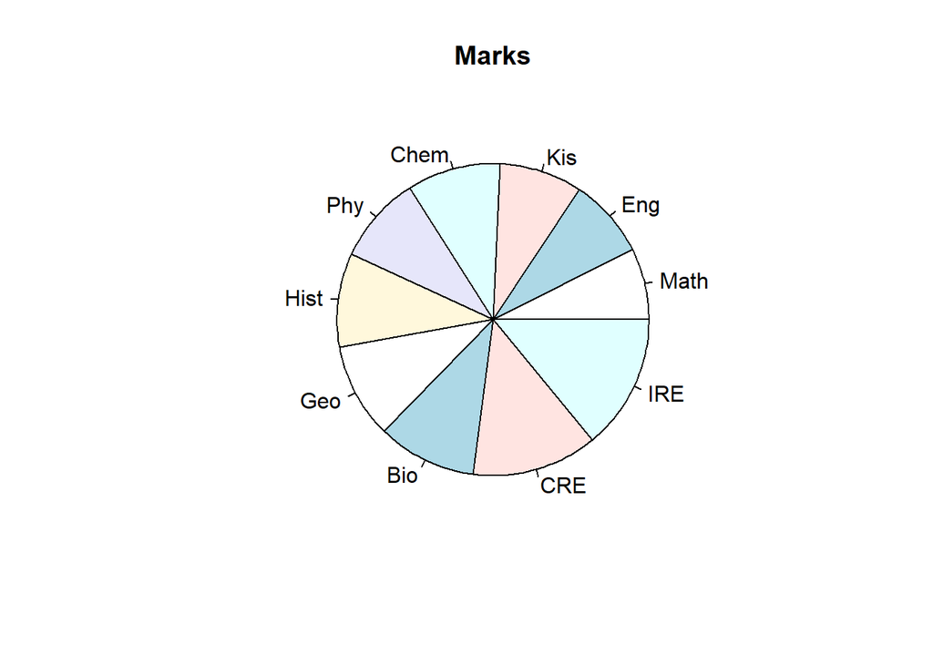

```r
# pie chart
pie(data$marks, labels = data$subject, main = "Marks")
```

### Interpretation

The pie chart displays the marks data as proportions of the whole. Each slice represents a subject, and the size of the slice corresponds to the proportion of that subject.

## Bar Plot

A bar plot is used to compare different categories or groups by displaying bars of varying lengths.

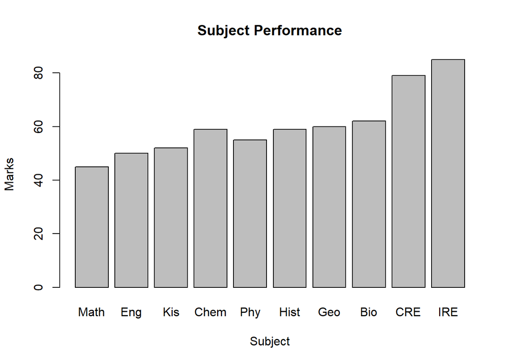

```r
# Bar plot
barplot(data$marks, names.arg = data$subject, main = "Subject Performance",
        xlab = "Subject", ylab = "Marks")
```

### Interpretation

The bar plot visually compares the marks of different subject. IRE has the highest marks and Math has the lowest.

## Boxplot

A boxplot summarizes the distribution of a continuous variable by displaying the median, quartiles, and outliers.

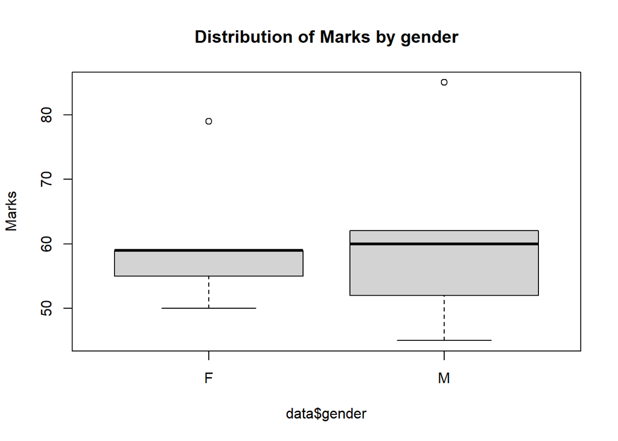

```r
# boxplot
boxplot(data$marks~data$gender, main = "Distribution of Marks by gender", ylab = "Marks")
```

### Interpretation

The boxplot shows the distribution of marks in each gender. It displays the median, quartiles, and any outliers. Male students have the highest mean value, followed by female.

## Histogram

A histogram visualizes the distribution of a continuous variable by grouping the data into bins and displaying the frequencies or densities of each bin.

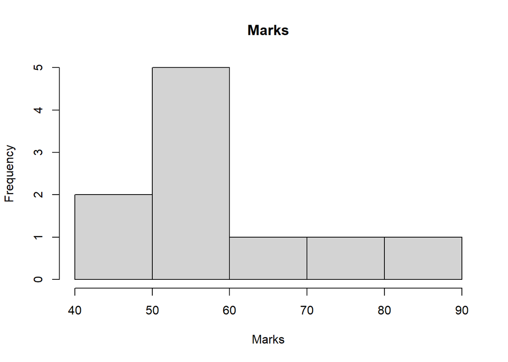

```r
# Histogram
hist(data$marks, main = "Marks", xlab = "Marks", ylab = "Frequency")
```

HURRAY! YOUR DONE WITH THE LESSON, PLEASE PROCEED TO THE ASSIGNMENT.